# individual2

Danny Nguyen

April 17, 2019

# Data preparation Accident

```r
acc <- read.csv("https://raw.githubusercontent.com/xdaiISU/ds202materials/master/hwlabs/fars2017/accident.csv", stringsAsFactors = FALSE)
names(acc)
```

```
##  [1] "STATE"      "ST_CASE"    "VE_TOTAL"   "VE_FORMS"   "PVH_INVL"
##  [6] "PEDS"       "PERNOTMVIT" "PERMVIT"    "PERSONS"    "COUNTY"
## [11] "CITY"       "DAY"        "MONTH"      "YEAR"       "DAY_WEEK"
## [16] "HOUR"       "MINUTE"     "NHS"        "RUR_URB"    "FUNC_SYS"
## [21] "RD_OWNER"   "ROUTE"      "TWAY_ID"    "TWAY_ID2"   "MILEPT"
## [26] "LATITUDE"   "LONGITUD"   "SP_JUR"     "HARM_EV"    "MAN_COLL"
## [31] "RELJCT1"    "RELJCT2"    "TYP_INT"    "WRK_ZONE"   "REL_ROAD"
## [36] "LGT_COND"   "WEATHER1"   "WEATHER2"   "WEATHER"    "SCH_BUS"
## [41] "RAIL"       "NOT_HOUR"   "NOT_MIN"    "ARR_HOUR"   "ARR_MIN"
## [46] "HOSP_HR"    "HOSP_MN"    "CF1"        "CF2"        "CF3"
## [51] "FATALS"     "DRUNK_DR"
```

```r
library(ggplot2)
library(dplyr)
library(tidyr)
library(readxl)
```

# Part 1: Accident data

# Q1: are there some days of the week where more accidents happen than on others (use variable DAY_WEEK)?

The bar chart right below the following code displays the number of accidents that have happened on each day of the week. The chart shows Saturday having the highest accident count with 5873 accidents. The supposedly “safest” day would be Wednesday having the number of 4314 accidents.

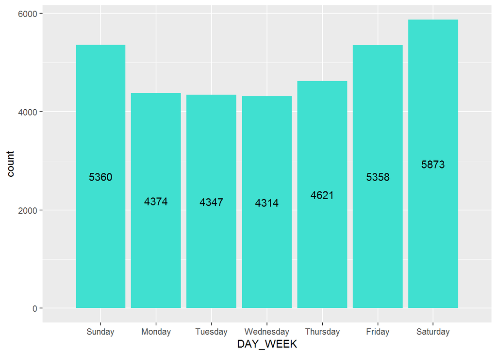

```r
ggplot(acc, aes(x = DAY_WEEK)) + geom_bar(stat = "count", fill = "turquoise") + geom_text(aes(label = ..count..), stat = "count", position = position_stack(0.5)) + scale_x_discrete(limits = c("Sunday","Monday","Tuesday","Wednesday","Thursday","Friday","Saturday"))
```

# Q2: what time of the day do accidents happen (use variable HOUR)?

The following bar chart displays the count of accidents for each hour. The hour with the most number of accidents is the 18th hour or 6 P.M. at 2000 accidents, and the hour with the least number of accidents is the 4th hour or 4 A.M. at 813 accidents.

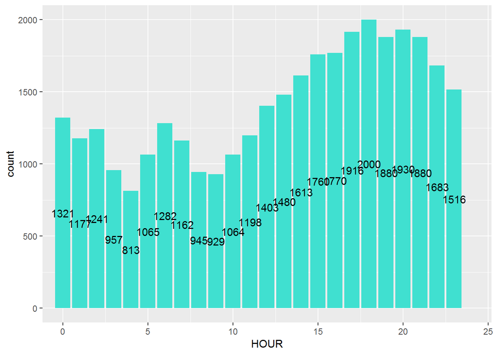

```r
ggplot(acc, aes(x = HOUR)) + geom_bar(stat = "count", fill = "turquoise") + geom_text(aes(label = ..count..), stat = "Count", position = position_stack(0.5)) + coord_cartesian(xlim = c(0, 24))
```

# Q3: what is the number of accidents with at least one drunk driver (use variable DRUNK_DR)?

The bar chart below displays the amount of drunk drivers per accident. The total count of accidents involving drunk drivers is from adding up 8513 + 249 + 7 which equals 8769.

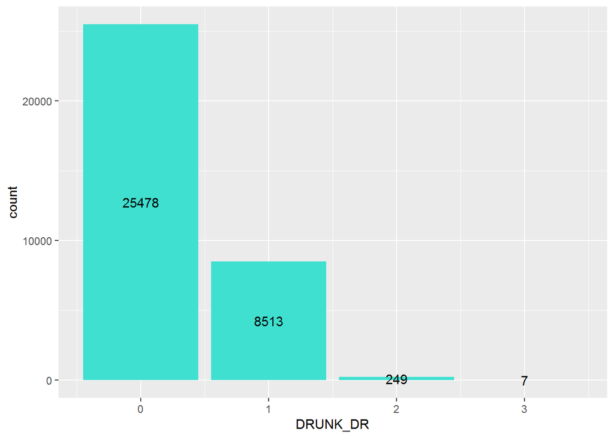

```r
ggplot(acc, aes(x = DRUNK_DR)) + geom_bar(stat = "count", fill = "turquoise") + geom_text(aes(label = ..count..), stat = "Count", position = position_stack(0.5))
```

# Part 2: Connecting data

# Q1: Load the person table. Identify drivers (PER_TYP == 1, see fars manual) and subset on them.

```r
#load person table
per <- read.csv("https://raw.githubusercontent.com/xdaiISU/ds202materials/master/hwlabs/fars2017/person.csv", stringsAsFactors = FALSE)
names(per)
```

```
##  [1] "STATE"      "ST_CASE"    "VE_FORMS"   "VEH_NO"     "PER_NO"
##  [6] "STR_VEH"    "COUNTY"     "DAY"        "MONTH"      "HOUR"
## [11] "MINUTE"     "RUR_URB"    "FUNC_SYS"   "HARM_EV"    "MAN_COLL"
## [16] "SCH_BUS"    "MAKE"       "MAK_MOD"    "BODY_TYP"   "MOD_YEAR"
## [21] "TOW_VEH"    "SPEC_USE"   "EMER_USE"   "ROLLOVER"   "IMPACT1"
## [26] "FIRE_EXP"   "AGE"        "SEX"        "PER_TYP"    "INJ_SEV"
## [31] "SEAT_POS"   "REST_USE"   "REST_MIS"   "AIR_BAG"    "EJECTION"
## [36] "EJ_PATH"    "EXTRICAT"   "DRINKING"   "ALC_DET"    "ALC_STATUS"
## [41] "ATST_TYP"   "ALC_RES"    "DRUGS"      "DRUG_DET"   "DSTATUS"
## [46] "DRUGTST1"   "DRUGTST2"   "DRUGTST3"   "DRUGRES1"   "DRUGRES2"
## [51] "DRUGRES3"   "HOSPITAL"   "DOA"        "DEATH_DA"   "DEATH_MO"
## [56] "DEATH_YR"   "DEATH_HR"   "DEATH_MN"   "DEATH_TM"   "LAG_HRS"
## [61] "LAG_MINS"   "P_SF1"      "P_SF2"      "P_SF3"      "WORK_INJ"
## [66] "HISPANIC"   "RACE"       "LOCATION"
```

```r
#subset of drivers
drivers <- per[per$PER_TYP == 1, c(29)]
summary(drivers)
```

```
##    Min. 1st Qu.  Median    Mean 3rd Qu.    Max.
##       1       1       1       1       1       1
```

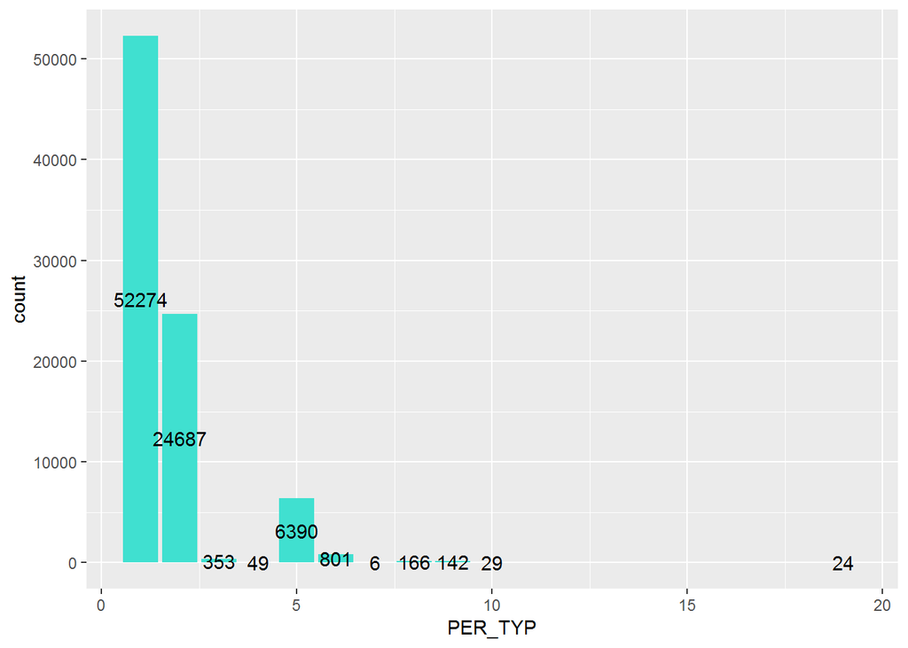

```r
#extra: visualization of the count of each PER_TYP.
ggplot(per, aes(x = PER_TYP)) + geom_bar(stat = "count", fill = "turquoise") + geom_text(aes(label = ..count..), stat = "count", position = position_stack(0.5))
```

# Q2: Join accident and driver table (work out which variable(s) to use)

```r
#the inner_join will result in joining the two tables by automatically matching up the same variables from both tables which are ("STATE", "ST_CASE", "VE_FORMS", "COUNTY", "DAY", "MONTH", "HOUR", "MINUTE", "RUR_URB", "FUNC_SYS", "HARM_EV", "MAN_COLL", "SCH_BUS")
drivAcci <- inner_join(acc, per)
```

# Q3: Tally the number of accidents by day of the week (DAY_WEEK), hour of the day (HOUR) and gender (SEX). Visualize the results!

```r
#total number of accidents based on Day of the Week, Hour of the Day, and Sex
sum(drivAcci$DAY_WEEK)
```

```
## [1] 351000
```

```r
sum(drivAcci$HOUR)
```

```
## [1] 1161947
```

```r
sum(drivAcci$SEX)
```

```
## [1] 124933
```

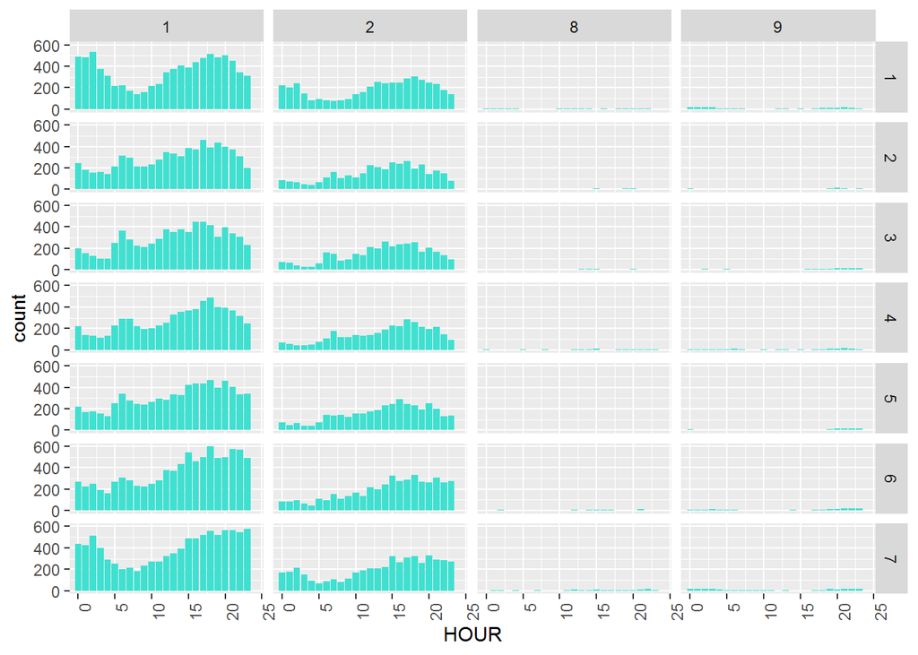

```r
#Facet Grid visual of Accidents for each hour for each day of the week and divided among the different sex classifications.

#The label code for gender report is 1 = male, 2 = female, 8 = not reported, and 9 = unknown

#The label code for day of the week is 1 = "Sunday", 2 = "Monday", 3 = "Tuesday", 4 = "Wednesday", 5 = "Thursday", 6 = "Friday", and  7 = "Saturday"

ggplot(drivAcci, aes(x = HOUR)) + geom_bar(stat = "count", fill = "turquoise") + theme(axis.text.x = element_text(angle = 90, hjust = 1)) + facet_grid(DAY_WEEK ~ SEX) + coord_cartesian(xlim = c(0, 24))
```

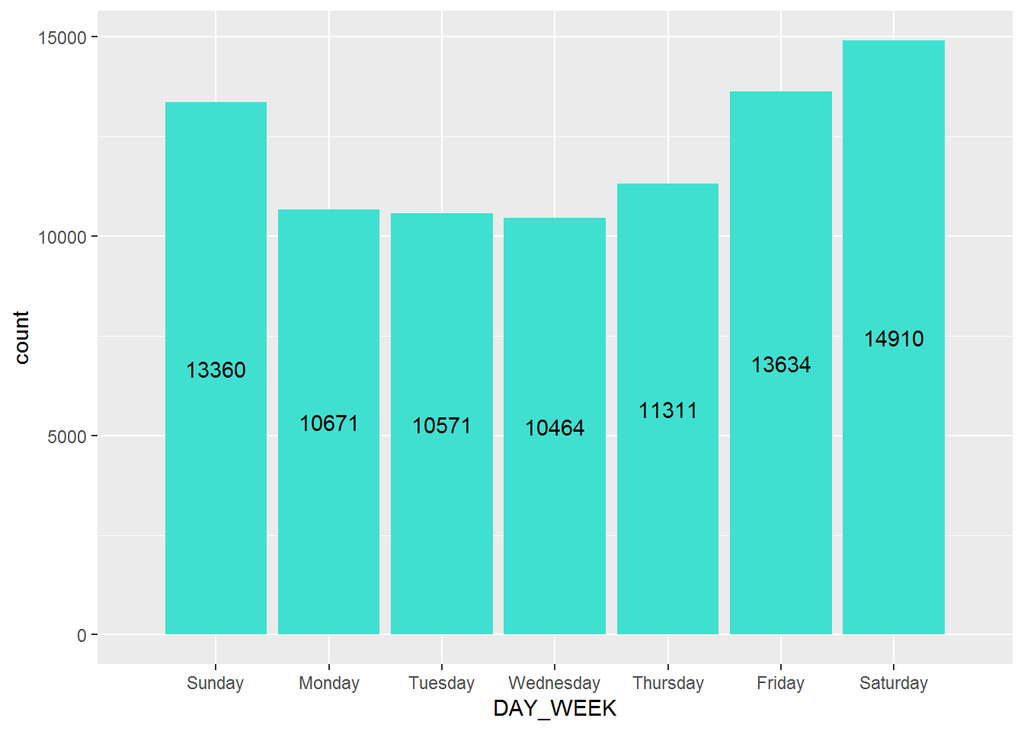

```r
#the three seperate visuals of accidents based on day of week, hour of day, and sex.
accWeek <- ggplot(drivAcci, aes(x = DAY_WEEK)) + geom_bar(stat = "count", fill = "turquoise") + geom_text(aes(label = ..count..), stat = "count", position = position_stack(0.5)) + scale_x_discrete(limits = c("Sunday","Monday","Tuesday","Wednesday","Thursday","Friday","Saturday"))

accHour <- ggplot(drivAcci, aes(x = HOUR)) + geom_bar(stat = "count", fill = "turquoise") + geom_text(aes(label = ..count..), stat = "count", position = position_stack(0.5)) + coord_cartesian(xlim = c(0, 24))

#The label code for gender report is 1 = male, 2 = female, 8 = not reported, and 9 = unknown
accSex <- ggplot(drivAcci, aes(x = SEX)) + geom_bar(stat = "count", fill = "turquoise") + geom_text(aes(label = ..count..), stat = "count", position = position_stack(0.5)) + facet_wrap(SEX ~ ., labeller = label_both)

accWeek #Number of accidents based on day of the week with data from the combined tables
```

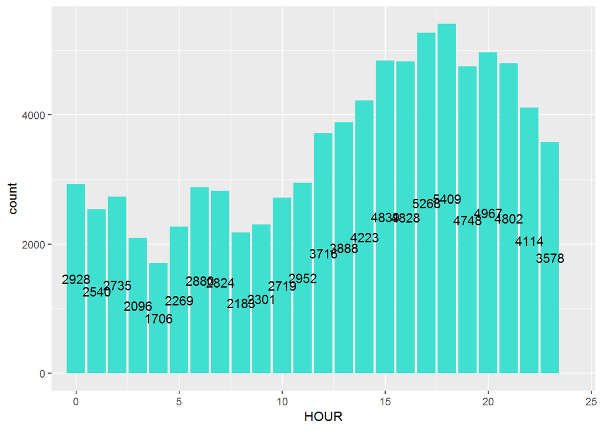

```r
accHour #Number of accidents based on hour of the day with data from the combined tables
```

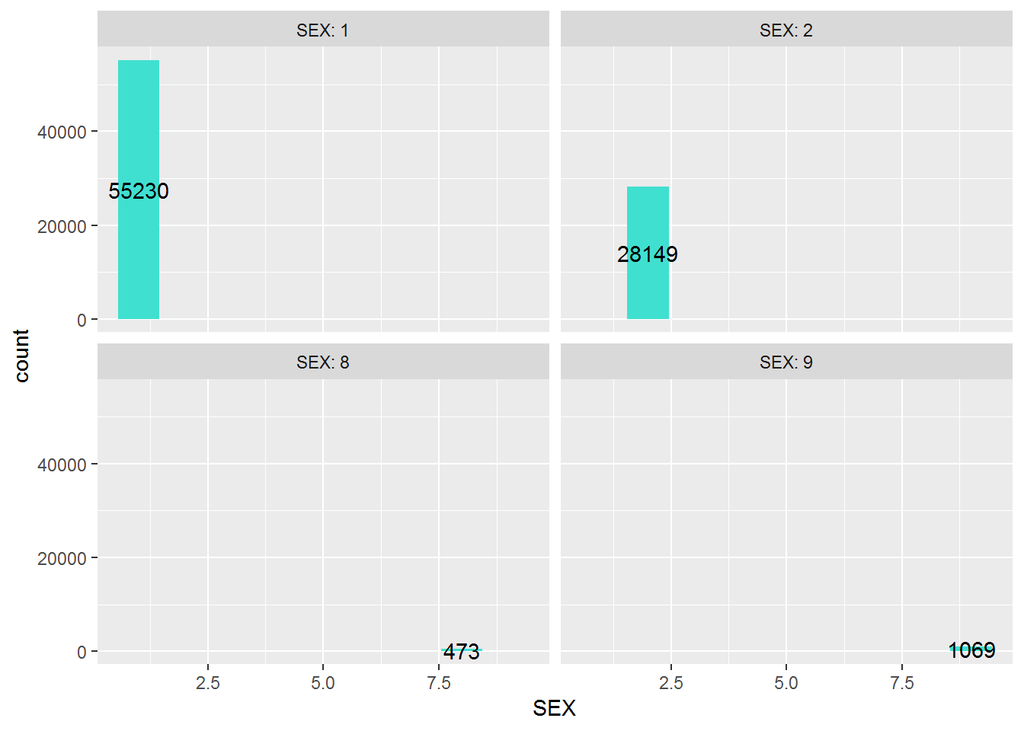

```r
#The label code for gender report is 1 = male, 2 = female, 8 = not reported, and 9 = unknown
accSex  #Number of accidents based on sex with data from the combined tables
```

# Part 3: Connecting data and make maps

# Q1:

It appears that the most amount of crashes happen throughout southern United States with a good deal of them happening in costal areas.

```r
glcs <- read_xlsx("FRPP GLC United States.xlsx", skip=1)
```

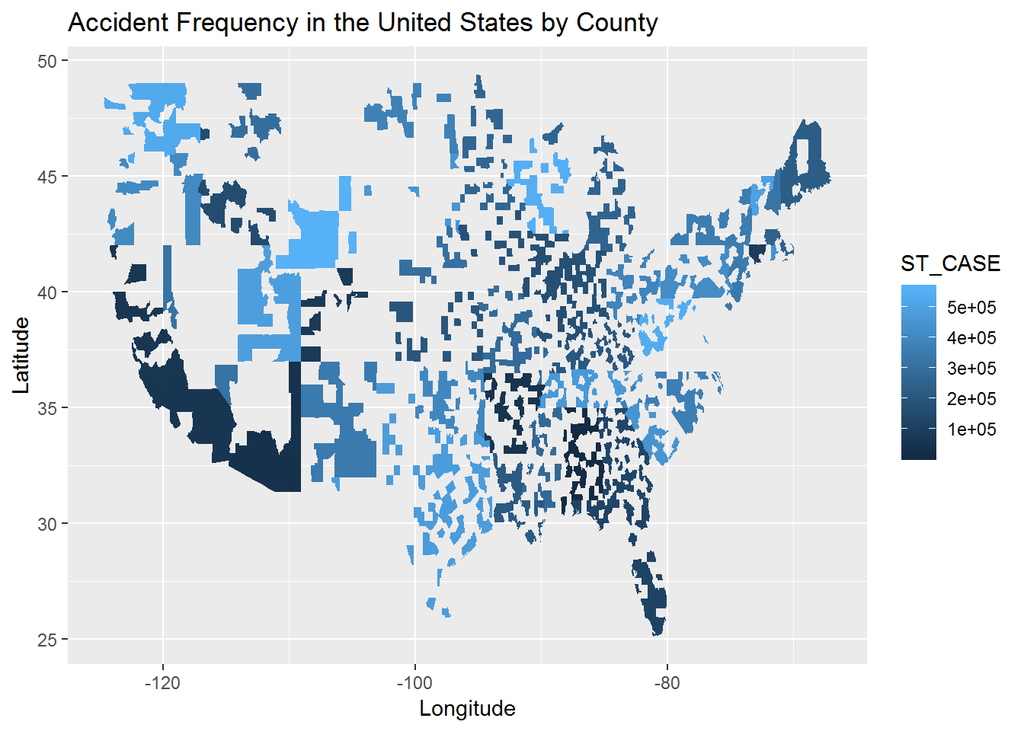

```r
counties <- map_data("county")
glcs$`State Code` <- as.numeric(glcs$`State Code`)
glcs$`County Code` <- as.numeric(glcs$`County Code`)
glcs$`City Code` <- as.numeric(glcs$`City Code`)
accGlcs <- left_join(acc, glcs, by = c("STATE" = "State Code", "COUNTY" = "County Code", "CITY" = "City Code"))

counties$region <- toupper(counties$region)
counties$subregion <- toupper(counties$subregion)
accident.map <- accGlcs %>% left_join(counties, by = c("State Name" = "region", "County Name" = "subregion"))

ggplot(accident.map, aes(x = long, y = lat, fill = ST_CASE)) + geom_polygon(aes(group = group)) + labs(title = "Accident Frequency in the United States by County", x = "Longitude", y = "Latitude")
```

# Q2: Can you find seasonal trends in accident occurrences in different states? Is summer or winter more dangerous? Why?

More crashes happen in summer, especially in June and July, than the other seasons. Originally expected winter to be the worst season, but even spring has more crashes.

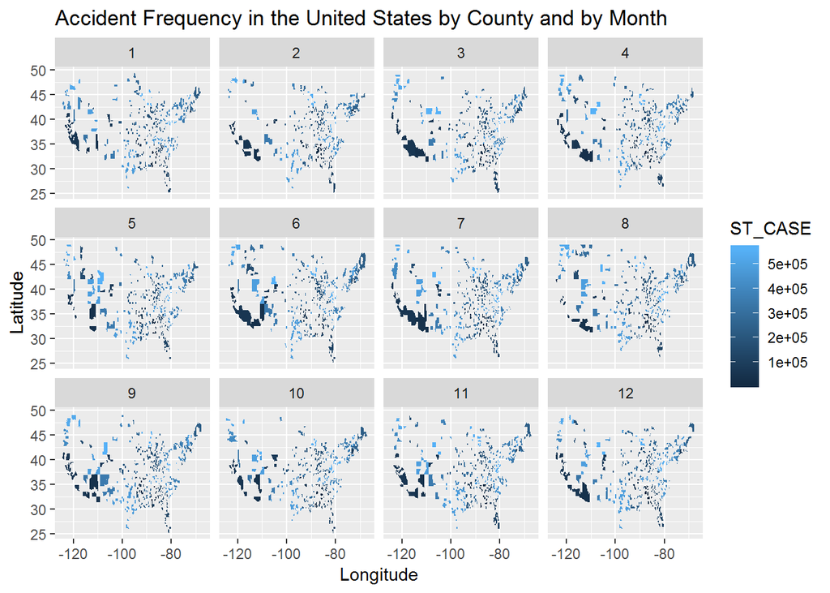

```r
ggplot(accident.map, aes(x = long, y = lat, fill = ST_CASE)) + geom_polygon(aes(group = group)) + labs(title = "Accident Frequency in the United States by County and by Month", x = "Longitude", y = "Latitude") + facet_wrap(~MONTH)
```